# Assignment 6: Parole Reform

- Show All Code
- Hide All Code
- View Source

MUSA 5080 · Fall 2026

Author

Chloe Alimurong

Published

November 24, 2026

# The scenario

The Georgia Department of Community Supervision is considering a risk model to guide parole decisions. Every person released to parole would get a predicted probability of being **rearrested within three years**. The department has two proposed uses:

- **Use A:** people above a threshold get **more restrictive supervision** (more check-ins, electronic monitoring, faster revocation).
- **Use B:** people above a threshold get **priority for reentry services** (housing assistance, job placement, a case manager).

The department has promised that the model **will not use race**. You’ve been hired to build it and to tell them whether that promise means what they think it means.

# The data

The National Institute of Justice’s **Recidivism Forecasting Challenge** data: 25,835 people released from Georgia prisons to parole supervision, 2013–2015. Download the CSV from Canvas, put it in your portfolio’s `data/` folder, and rename it `nij_recidivism.csv`.

A few things to know before you start:

- **Race is recorded only as Black or white.** The data includes no one else.
- **Counts are top-coded:** “10 or more” prior felony arrests is stored as text. `parse_number()` turns it into 10, which undercounts people with many more.
- **`Residence_PUMA`** is not a census PUMA code. NIJ grouped Georgia’s PUMAs into 25 areas and numbered them 1–25 to protect privacy. You can use it to group people by place, but you can’t map it.
- **`Training_Sample`** is NIJ’s own train/test split. Use it.

# Part 1: Load and clean

**1.1**

There are 18,028 observations in the training set and 7,807 in the test set. 58% of people in the training and 57% test set was rearrested within three years. This was calculated by extracting the total of people rearrested with more than 3 years (‘Recidivism_Within_3years’) from the total observations of each set, then dividing that number by the total which was roughly 0.58 for the training and 0.57 for the test (10,421 in the training set and 4,483 in the test set.)

**1.2** Look at `Gang_Affiliated`. How many values are missing, and who are they? (Hint: cross-tabulate it with `Gender`.) What would happen to your sample if you added this variable to a model without handling the missing values?

```
[1] 3167
```

```
[1] 3167
```

There are 3,167 missing values for ‘Gang_Affiliated’, they are the women in this dataset. If we added this variable to a model without handling the missing values, the model would be inherently biased towards the male subjects in our data.

# Part 2: What would you know at the moment of decision?

The parole decision happens **at release**. Some columns in this file were recorded **during** the three years of supervision that followed.

**2.1**

| Known at release | Recorded during supervision (leakage) |
| --- | --- |
| ID | Recidivism_Within_3years |
| Gender | Recidivism_Arrest_Year1 |
| Race | Recidivism_Arrest_Year2 |
| Age_at_Release | Recidivism_Arrest_Year3 |
| Residence_PUMA | Gang_Affiliated |
| Education_Level | Supervision_Risk_Score_First |
| Prison_Offense | Supervision_Level_First |
| Prison_Years | Condition_MH_SA |
| Dependents | Condition_Cog_Ed |
| Prior_Arrest_Episodes_Felony | Condition_Other |
| Prior_Arrest_Episodes_Misd | Violations_ElectronicMonitoring |
| Prior_Arrest_Episodes_Violent | Violations_Instruction |
| Prior_Arrest_Episodes_Property | Violations_FailToReport |
| Prior_Arrest_Episodes_Drug | Violations_MoveWithoutPermission |
| Prior_Arrest_Episodes_PPViolationCharges | Delinquency_Reports |
| Prior_Arrest_Episodes_DVCharges | Program_Attendances |
| Prior_Arrest_Episodes_GunCharges | Program_UnexcusedAbsences |
| Prior_Conviction_Episodes_Felony | Residence_Changes |
| Prior_Conviction_Episodes_Misd | Avg_Days_per_DrugTest |
| Prior_Conviction_Episodes_Viol | DrugTests_THC_Positive |
| Prior_Conviction_Episodes_Prop | DrugTests_Cocaine_Positive |
| Prior_Conviction_Episodes_Drug | DrugTests_Meth_Positive |
| Prior_Conviction_Episodes_PPViolationCharges | DrugTests_Other_Positive |
| Prior_Conviction_Episodes_DomesticViolenceCharges | Percent_Days_Employed |
| Prior_Conviction_Episodes_GunCharges | Jobs_Per_Year |
| Prior_Revocations_Parole | Employment_Exempt |
| Prior_Revocations_Probation |  |

**2.2** Pick one variable from the right-hand column and explain, in two sentences, why including it would make your model look better than it really is.

*Your answer:* Variables like ‘Recidivism_Arrest_Year3’ would make the model’s performance look better because if they have been arrested within 3 years again, then we would have the better probability of predicting recidivism within 3 years since there’s already data on it. The problem in using variables to be recorded after our prediction and ones so close to our prediction, is that the outcomes we predict are modeled after ones that already happened. So we would get high numbers because those outcomes happened in our training and test sets but not when we test in real life.

# Part 3: Build a race-blind model

```r
base_fit <- glm(recid ~ male + age_group + prison_years +
                  prior_fel_arrests + prior_misd_arrests,
                family = binomial,
                data = train)

summary(base_fit)
```

```
Call:
glm(formula = recid ~ male + age_group + prison_years + prior_fel_arrests +
    prior_misd_arrests, family = binomial, data = train)

Coefficients:
                                       Estimate Std. Error z value Pr(>|z|)
(Intercept)                           -0.031637   0.078824  -0.401  0.68815
male                                   0.454123   0.049610   9.154  < 2e-16 ***
age_group23-27                        -0.505516   0.070835  -7.137 9.57e-13 ***
age_group28-32                        -1.062281   0.072975 -14.557  < 2e-16 ***
age_group33-37                        -1.448176   0.076123 -19.024  < 2e-16 ***
age_group38-42                        -1.678820   0.081802 -20.523  < 2e-16 ***
age_group43-47                        -1.910151   0.084204 -22.685  < 2e-16 ***
age_group48 or older                  -2.290828   0.080526 -28.448  < 2e-16 ***
prison_years1-2 years                 -0.124180   0.041760  -2.974  0.00294 **
prison_yearsGreater than 2 to 3 years -0.304194   0.049685  -6.122 9.22e-10 ***
prison_yearsMore than 3 years         -0.319948   0.047298  -6.765 1.34e-11 ***
prior_fel_arrests                      0.167507   0.006573  25.483  < 2e-16 ***
prior_misd_arrests                     0.131496   0.008719  15.081  < 2e-16 ***
---
Signif. codes:  0 '***' 0.001 '**' 0.01 '*' 0.05 '.' 0.1 ' ' 1

(Dispersion parameter for binomial family taken to be 1)

    Null deviance: 24551  on 18027  degrees of freedom
Residual deviance: 21940  on 18015  degrees of freedom
AIC: 21966

Number of Fisher Scoring iterations: 4
```

**3.1** Exponentiate the coefficients. Interpret the odds ratio for `prior_fel_arrests` in one sentence, using the word *odds* correctly.

```r
exp(coef(base_fit))
```

```
                          (Intercept)                                  male
                            0.9688582                             1.5747917
                       age_group23-27                        age_group28-32
                            0.6031942                             0.3456664
                       age_group33-37                        age_group38-42
                            0.2349986                             0.1865940
                       age_group43-47                  age_group48 or older
                            0.1480580                             0.1011826
                prison_years1-2 years prison_yearsGreater than 2 to 3 years
                            0.8832206                             0.7377176
        prison_yearsMore than 3 years                     prior_fel_arrests
                            0.7261868                             1.1823530
                   prior_misd_arrests
                            1.1405337
```

*Your answer:* For every one prior felony arrests, the odds of being arrested again within three years are 18% higher.

**3.2** Constant on the odds, not on the probability. Use `predict(..., type = "response")` with `newdata` to compute the predicted probability for two made-up people, then add one prior felony arrest to each:

- a man, age 23–27, 1–2 years in prison, 2 prior felony arrests, 1 misdemeanor arrest
- a man, age 48 or older, 1–2 years in prison, 2 prior felony arrests, 1 misdemeanor arrest

How much does one more arrest change each person’s probability? Why are the two changes different?

```r
people <- tibble(
  male               = c(1, 1),
  age_group          = factor(c("23-27", "48 or older"), levels = levels(nij$age_group)),
  prison_years       = factor(c("1-2 years", "1-2 years"), levels = levels(nij$prison_years)),
  prior_fel_arrests  = c(2, 2),
  prior_misd_arrests = c(1, 1)
)

people_2 <- people %>% mutate(prior_fel_arrests = prior_fel_arrests + 1)

results <- tibble(
  age_group = people$age_group,
  before    = predict(base_fit, newdata = people,   type = "response"),
  after     = predict(base_fit, newdata = people_2, type = "response"),
  change    = after - before
)

results
```

```
# A tibble: 2 × 4
  age_group   before after change
  <fct>        <dbl> <dbl>  <dbl>
1 23-27        0.564 0.605 0.0406
2 48 or older  0.179 0.204 0.0259
```

**3.3**

```r
train <- train %>%
  mutate(Dependents = replace_na(Dependents, 'None')) %>%
  mutate(Program_Attendances = replace_na(Program_Attendances, 'No attendances recorded'))

my_fit <- glm(recid ~ male + age_group + prison_years +
                  prior_fel_arrests + prior_misd_arrests + Education_Level + Dependents + Program_Attendances,
                family = binomial,
                data = train)

summary(my_fit)
```

```
Call:
glm(formula = recid ~ male + age_group + prison_years + prior_fel_arrests +
    prior_misd_arrests + Education_Level + Dependents + Program_Attendances,
    family = binomial, data = train)

Coefficients:
                                       Estimate Std. Error z value Pr(>|z|)
(Intercept)                           -0.097716   0.089018  -1.098  0.27233
male                                   0.446747   0.050072   8.922  < 2e-16 ***
age_group23-27                        -0.495129   0.071484  -6.926 4.32e-12 ***
age_group28-32                        -1.054181   0.074272 -14.193  < 2e-16 ***
age_group33-37                        -1.433464   0.077997 -18.378  < 2e-16 ***
age_group38-42                        -1.662654   0.084125 -19.764  < 2e-16 ***
age_group43-47                        -1.889817   0.086274 -21.905  < 2e-16 ***
age_group48 or older                  -2.262674   0.082481 -27.433  < 2e-16 ***
prison_years1-2 years                 -0.111777   0.042093  -2.655  0.00792 **
prison_yearsGreater than 2 to 3 years -0.286971   0.050061  -5.732 9.90e-09 ***
prison_yearsMore than 3 years         -0.290643   0.047700  -6.093 1.11e-09 ***
prior_fel_arrests                      0.163479   0.006659  24.549  < 2e-16 ***
prior_misd_arrests                     0.128858   0.008800  14.642  < 2e-16 ***
Education_LevelHigh School Diploma     0.228824   0.046981   4.871 1.11e-06 ***
Education_LevelLess than HS diploma    0.090137   0.048507   1.858  0.06314 .
Dependents1                            0.048173   0.046464   1.037  0.29983
Dependents2                            0.047468   0.049080   0.967  0.33347
Dependents3 or more                    0.011726   0.042896   0.273  0.78457
Program_Attendances1                   0.221526   0.088428   2.505  0.01224 *
Program_Attendances10 or more         -0.451263   0.050786  -8.886  < 2e-16 ***
Program_Attendances2                   0.102308   0.095209   1.075  0.28257
Program_Attendances3                   0.266627   0.111039   2.401  0.01634 *
Program_Attendances4                  -0.071218   0.097264  -0.732  0.46404
Program_Attendances5                   0.055553   0.081406   0.682  0.49497
Program_Attendances6                  -0.291237   0.053329  -5.461 4.73e-08 ***
Program_Attendances7                  -0.185909   0.092776  -2.004  0.04509 *
Program_Attendances8                  -0.072790   0.126320  -0.576  0.56446
Program_Attendances9                  -0.026279   0.127909  -0.205  0.83722
---
Signif. codes:  0 '***' 0.001 '**' 0.01 '*' 0.05 '.' 0.1 ' ' 1

(Dispersion parameter for binomial family taken to be 1)

    Null deviance: 24551  on 18027  degrees of freedom
Residual deviance: 21780  on 18000  degrees of freedom
AIC: 21836

Number of Fisher Scoring iterations: 4
```

# Part 4: Choosing a threshold

```r
test <- test %>%
  mutate(p_hat   = predict(my_fit, newdata = test, type = "response"),
         pred_50 = as.integer(p_hat >= 0.5))

# confusion matrix: rows = model's prediction, columns = what actually happened
table(predicted = test$pred_50, actual = test$recid)
```

```
         actual
predicted    0    1
        0 1518  819
        1 1806 3664
```

```r
test %>%
  summarize(
    sensitivity = sum(pred_50 == 1 & recid == 1) / sum(recid == 1),
    specificity = sum(pred_50 == 0 & recid == 0) / sum(recid == 0),
    accuracy    = mean(pred_50 == recid)
  )
```

```
# A tibble: 1 × 3
  sensitivity specificity accuracy
        <dbl>       <dbl>    <dbl>
1       0.817       0.457    0.664
```

*Your answer:* At a threshold of 0.5, the model correctly flags 3,664 of the 4,483 people who were rearrested (sensitivity = 0.82) and correctly clears 1,518 of the 3,324 people who were not rearrested (specificity = 0.46). It wrongly flags 1,806 people and misses 819. Overall accuracy is 0.66, or 5,182 correct out of 7,807.

**4.2** What share of the test set does your model label “high risk” at 0.5? Compare it to the share actually rearrested. What does that tell you about 0.5 as a default for this data?

*Your answer:* At 0.5, the model labels 5,470 of 7,807 people, or about 70%, as high risk. In the test set, 4,483 people, or about 57%, were actually rearrested, so the model flags about 13 points more people than were really rearrested. Among people who were not rearrested, about 54% were still labeled high risk. Because more than half of this group is rearrested, 0.5 is a low bar for this data: it labels most people high risk and wrongly flags more than half of those who stayed out of trouble. A higher threshold would flag fewer people and cut down the wrong flags, at the cost of missing more people who are rearrested.

**4.3** Computing sensitivity and specificity for every threshold from 0.30 to 0.80 in steps of 0.05, and plot both lines on one chart with threshold on the x-axis.

```r
rates_at <- function(data, threshold) {
  data %>%
    mutate(flag = as.integer(p_hat >= threshold)) %>%
    summarize(
      threshold = threshold,
      sensitivity = sum(flag == 1 & recid == 1) / sum(recid == 1),
      specificity = sum(flag == 0 & recid == 0) / sum(recid == 0),
      accuracy = mean(flag == recid)
    )
}

thresholds <- seq(0.30, 0.80, by = 0.05)
sweep <- map_dfr(thresholds, function(t) rates_at(test, t))
sweep
```

```
# A tibble: 11 × 4
   threshold sensitivity specificity accuracy
       <dbl>       <dbl>       <dbl>    <dbl>
 1      0.3        0.960       0.192    0.633
 2      0.35       0.940       0.244    0.644
 3      0.4        0.908       0.309    0.653
 4      0.45       0.870       0.377    0.660
 5      0.5        0.817       0.457    0.664
 6      0.55       0.746       0.549    0.662
 7      0.6        0.653       0.644    0.650
 8      0.65       0.533       0.740    0.621
 9      0.7        0.402       0.827    0.583
10      0.75       0.270       0.903    0.540
11      0.8        0.145       0.958    0.491
```

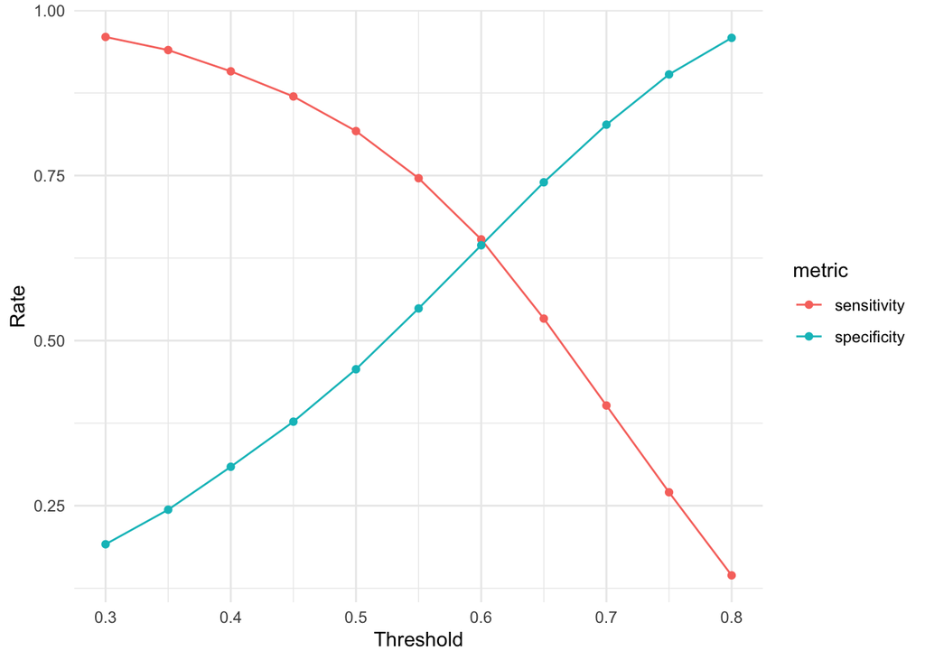

```r
sweep %>%
  pivot_longer(c(sensitivity, specificity), names_to = "metric", values_to = "rate") %>%
  ggplot(aes(threshold, rate, color = metric)) +
  geom_line() + geom_point() +
  theme_minimal() +
  labs(x = "Threshold", y = "Rate")
```

**4.4** Plot the ROC curve for `my_fit` on the test set with `pROC` and report the AUC. In one sentence: what does the AUC tell you, and what doesn’t it tell you about the decision the department has to make?

```r
roc_obj <- roc(test$recid, test$p_hat)
auc(roc_obj)
```

```
Area under the curve: 0.7042
```

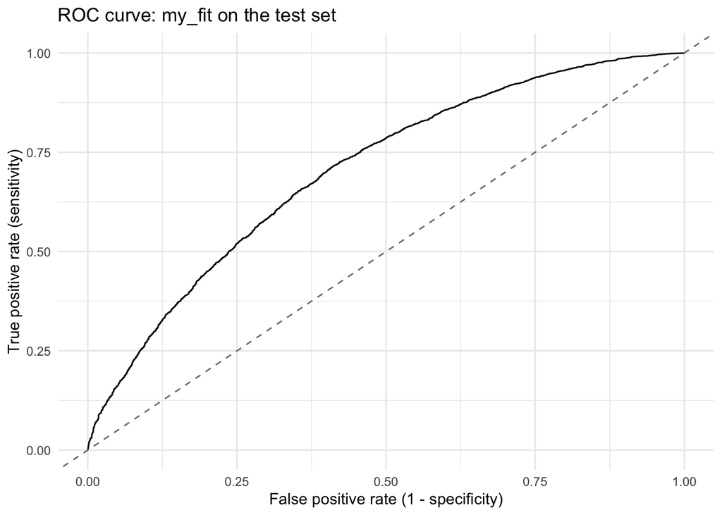

```r
ggroc(roc_obj, legacy.axes = TRUE) +
  geom_abline(linetype = "dashed", color = "grey50") +
  labs(x = "False positive rate (1 - specificity)",
       y = "True positive rate (sensitivity)",
       title = "ROC curve: my_fit on the test set") +
  theme_minimal()
```

*Your answer:* The area under the curve (AUC) is 0.7042 tells me that there is a 70% probability that my model, if given a random person that was rearrested or not, will rank the rearrested higher than those who were not resarrested. However, the AUC doesn’t provide a standard threshold to use for Use A or Use B because the errors from those thresholds may affect people based on race differently.

# Part 5: Is it race-blind?

Race isn’t in your model. Now check the errors by race on the **test set**.

**5.1** At the threshold of 0.5, compute for each race: the share labeled high risk, the share actually rearrested, the **false positive rate** (labeled high risk, not rearrested, out of everyone not rearrested), and the **false negative rate**.

```r
test %>%
  filter(Race %in% c('BLACK', 'WHITE')) %>%
  mutate(flag=as.integer(p_hat>=0.5)) %>%
  group_by(Race) %>%
  summarize(
    n= n(),
    base_rate = mean(recid),
    fpr = sum(flag == 1 & recid == 0) / sum(recid ==0),
    fnr = sum(flag == 0 & recid == 1) / sum(recid ==1),
    accuracy = mean(flag == recid)
  )
```

```
# A tibble: 2 × 6
  Race      n base_rate   fpr   fnr accuracy
  <chr> <int>     <dbl> <dbl> <dbl>    <dbl>
1 BLACK  4534     0.582 0.584 0.166    0.659
2 WHITE  3273     0.564 0.490 0.207    0.670
```

**5.2** Repeat 5.1 at two other thresholds from your sweep. Does the gap between groups close, stay, or flip?

```r
test %>%
  filter(Race %in% c('BLACK', 'WHITE')) %>%
  mutate(flag=as.integer(p_hat>=0.3)) %>%
  group_by(Race) %>%
  summarize(
    n= n(),
    base_rate = mean(recid),
    fpr = sum(flag == 1 & recid == 0) / sum(recid ==0),
    fnr = sum(flag == 0 & recid == 1) / sum(recid ==1),
    accuracy = mean(flag == recid)
  )
```

```
# A tibble: 2 × 6
  Race      n base_rate   fpr    fnr accuracy
  <chr> <int>     <dbl> <dbl>  <dbl>    <dbl>
1 BLACK  4534     0.582 0.846 0.0338    0.627
2 WHITE  3273     0.564 0.759 0.0493    0.641
```

```r
test %>%
  filter(Race %in% c('BLACK', 'WHITE')) %>%
  mutate(flag=as.integer(p_hat>=0.8)) %>%
  group_by(Race) %>%
  summarize(
    n= n(),
    base_rate = mean(recid),
    fpr = sum(flag == 1 & recid == 0) / sum(recid ==0),
    fnr = sum(flag == 0 & recid == 1) / sum(recid ==1),
    accuracy = mean(flag == recid)
  )
```

```
# A tibble: 2 × 6
  Race      n base_rate    fpr   fnr accuracy
  <chr> <int>     <dbl>  <dbl> <dbl>    <dbl>
1 BLACK  4534     0.582 0.0496 0.850    0.485
2 WHITE  3273     0.564 0.0308 0.863    0.500
```

*Your answer:* The accuracy rate for the 0.3 threshold (63% and 64%) is slightly lower than the 0.5 threshold (66% and 67%) but the accuracy for the 0.8 threshold is much lower (49% and 50%). I notice the fpr and fnr distributions for the 0.3 and 0.8 thresholds flip, with the 0.3 threshold having higher overall fpr and low fnr and 0.8 having a high fnr and low fpr.

**5.3** Investigate at least two candidates by comparing their distributions by race. Possibilities include age, prior arrests, prison offense, and place (`puma`). Show your evidence with a table or chart for each.

```r
# Candidate 1: prior felony arrests
test %>%
  group_by(Race) %>%
  summarize(mean_prior_fel  = mean(prior_fel_arrests),
            mean_prior_misd = mean(prior_misd_arrests),
            share_5plus_fel = mean(prior_fel_arrests >= 5),
            n = n())
```

```
# A tibble: 2 × 5
  Race  mean_prior_fel mean_prior_misd share_5plus_fel     n
  <chr>          <dbl>           <dbl>           <dbl> <int>
1 BLACK           5.70            3.16           0.581  4534
2 WHITE           5.84            3.55           0.613  3273
```

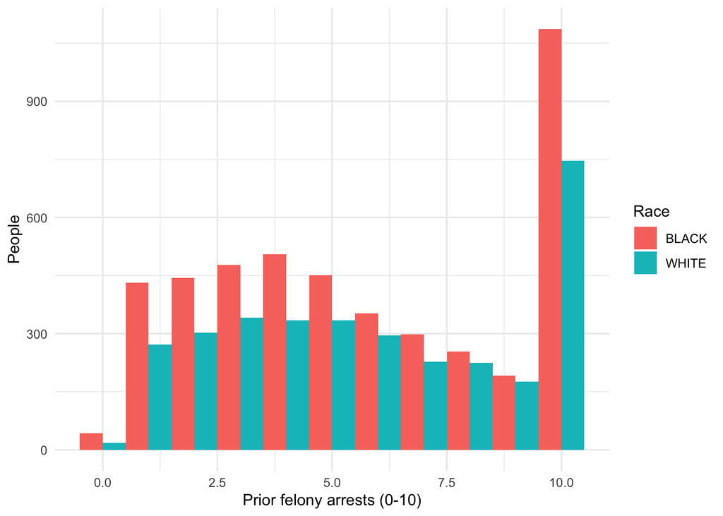

```r
ggplot(test, aes(prior_fel_arrests, fill = Race)) +
  geom_histogram(position = "dodge", bins = 11) +
  theme_minimal() +
  labs(x = "Prior felony arrests (0-10)", y = "People")
```

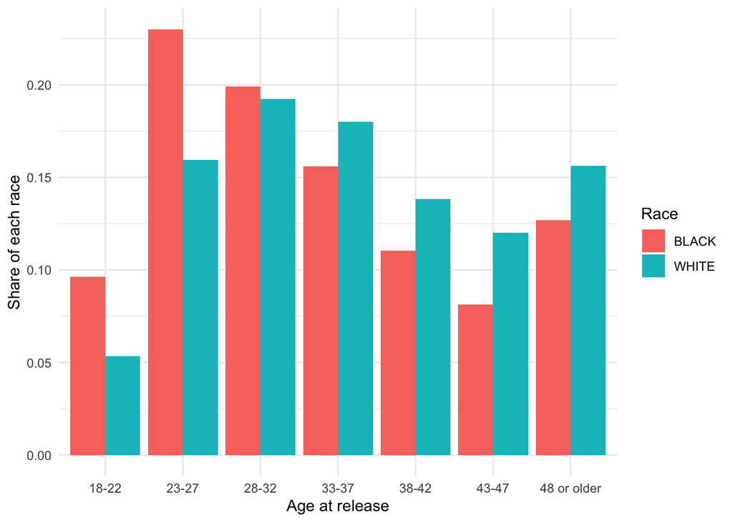

```r
# Candidate 2: age at release
test %>%
  count(Race, age_group) %>%
  group_by(Race) %>%
  mutate(share = n / sum(n)) %>%
  ggplot(aes(age_group, share, fill = Race)) +
  geom_col(position = "dodge") +
  theme_minimal() +
  labs(x = "Age at release", y = "Share of each race")
```

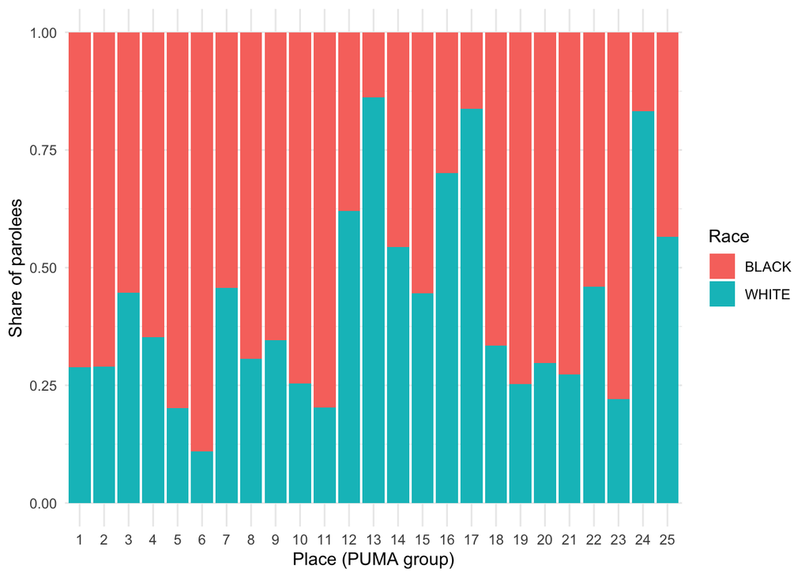

```r
# Candidate 3: place
test %>%
  count(puma, Race) %>%
  group_by(puma) %>%
  mutate(share = n / sum(n)) %>%
  ggplot(aes(puma, share, fill = Race)) +
  geom_col() +
  theme_minimal() +
  labs(x = "Place (PUMA group)", y = "Share of parolees")
```

*Your answer:* White people in our test set have slightly more prior arrests than Black people on average (5.84 vs. 5.70 felonies, 3.55 vs. 3.16 misdemeanors), so the histogram’s taller Black bars just reflect that there are more Black people in our test set overall. For age groups, Black people skew younger, and the model likely gives younger people higher risk which raises risk scores for Black people since there are more observations of them in our test set. The model’s odds of rearrest fall steadily with age, from 39% lower for ages 23-27 to 90% lower for ages 48 and older, compared with ages 18-22. Black parolees skew younger, so age is one way the model gives them higher scores without using race. The racial mix differs a lot by place, from PUMA 6 where Black people are about 89% to PUMAs 13, 17 and 24 where white people are about 83-86%, so any model that uses place would carry information about race.